# Homework 6

Ben Ridenhour

03-Nov-21

# Simulating an SIR model using a Markov Chain

This homework revolved around looking at stochastic dynamics produced by simulating a discrete system of equations using a Markov chain. Recollect that the SIR system is

$$\begin{align}
\Delta S &= -\beta S \frac{I}{N} \\
\Delta I &= \beta S \frac{I}{N} - \gamma I \\
(\Delta R &= \gamma I).
\end{align}$$
Also, remember that it isn’t necessary to track the changes in the $R$ (recovered) class because it is a closed system, i.e., $N = S + I + R$ is conserved.

# Comparing the Gillespie Algorithm with tau Leaping

The first part of the homework asks you to compare results from the Gillespie algorithm and the tau-leaping algorithm. Parameters for the system are as follows:

1. $N = 500$
2. $\beta = 1/5$
3. $\gamma = 2/15$
4. $S(0) = 499, I(0)=1$.

Finally, the Markov chains should stop once $I = 0$ and 20 replicates of each algorithm should be run. Let’s set up the code to run the two algorithms.

## Writing the Alogorithms

The Gillespie algorithm:

```python
import pandas as pd
import numpy as np
import numpy.linalg as nla #scipy also provides linear algebra capabilities
import matplotlib.pyplot as plt

def probMass(state, beta = 1/5, gamma = 2/15, N = 500): return np.array([beta*state['S']*state['I']/N, gamma*state['I']]).reshape(-1)


def update(theta, **kwargs):
  state, Time = theta.values()
  pr = probMass(state, **kwargs)
  P = pr / pr.sum()
  rxnIndex = np.random.choice(range(2), p=P)
  rxnVec = np.zeros(pr.size)
  rxnVec[rxnIndex] = 1
  transition = np.array([-1,1,0,-1]).reshape(2,-1,order='F')
  return {'state': state + transition @ rxnVec, 'Time': Time - np.log(np.random.uniform())/pr.sum()}

state0 = pd.DataFrame({"S":[499],"I":[1]}) #initial state
system0 = {"state":state0, "Time": 0}

update(system0)
```

```
{'state':        S    I
0  498.0  2.0, 'Time': 2.422399448102761}
```

It looks like the Gillespie algorithm worked. Now we define the tau leaping algorithm:

```python
def transProb(state, variance = False,  beta = 1/5, gamma = 2/15, N = 500): return (np.array([-1,1,0,-1]).reshape(2,-1,order='F')**(2**variance) @ np.diag([beta*state['I'].values[0]/N,gamma])).sum(axis=1) * state.to_numpy().reshape(-1)

def update_leaping(theta, epsilon = 0.03, g = np.array([2,2]), **kwargs):
  state, Time = theta.values()
  mu = transProb(state, **kwargs)
  var = transProb(state, variance=True)
  L = np.maximum(epsilon*state/g,1)
  tau = np.min(np.concatenate((L/np.abs(mu), L**2/var)))
  #advance the chain
  rxnVec = np.random.poisson(probMass(state, **kwargs)*tau, 2)
  transition = np.array([-1,1,0,-1]).reshape(2,-1,order='F')
  out = state + transition @ rxnVec
  #failsafe to keep values positive
  while (np.min(out) < 0).any() :
    tau = tau/2 #cut time step in half
    rxnVec = np.random.poisson(probMass(state)*tau, 2)
    out = state + transition @ rxnVec
  return {'state': out, 'Time': Time+tau}


update_leaping(system0)
```

```
{'state':      S  I
0  496  4, 'Time': 7.477567298105682}
```

```python
update_leaping(system0, epsilon = .2)
```

```
{'state':      S  I
0  497  2, 'Time': 7.477567298105682}
```

It looks like both of the algorithms are working as expected.

## Simulation and Comparison

So the problem asks for 20 iterations of each algorithm. We can handle this using a single for loop. Note that, because the stopping condition for the chain is $I = 0$, we use a `while` loop to iterate the Markov chains.

```python
np.random.seed(39457)

finalData = pd.DataFrame(columns = ["Method","Iteration","S","I","Time"])
for j in range(20):
  SIR = pd.DataFrame(columns=['Time','S','I'])
  SIR = SIR.append(pd.DataFrame({'Time': system0['Time'], 'S': system0['state']['S'], 'I': system0['state']['I']}), ignore_index = True)

  system = system0 #reset to initial condition
  while SIR.I.iloc[-1]  > 0:
    system = update_leaping(system)
    SIR = SIR.append(pd.DataFrame({'Time': system['Time'], 'S': system['state']['S'], 'I': system['state']['I']}), ignore_index = True)

  SIR['Method'] = "Tau"
  SIR['Iteration'] = j

  finalData = finalData.append(SIR,ignore_index=True)

  SIR = pd.DataFrame(columns=['Time','S','I'])
  SIR = SIR.append(pd.DataFrame({'Time': system0['Time'], 'S': system0['state']['S'], 'I': system0['state']['I']}), ignore_index = True)

  system = system0 #reset to initial condition
  while SIR.I.iloc[-1]  > 0:
    system = update(system)
    SIR = SIR.append(pd.DataFrame({'Time': system['Time'], 'S': system['state']['S'], 'I': system['state']['I']}), ignore_index = True)

  SIR['Method'] = "Gillespie"
  SIR['Iteration'] = j

  finalData = finalData.append(SIR,ignore_index=True)
```

How many iterations did it take each algorithm to complete?

Here is the count of the steps each algorithm took to finish:

```python
IterCount = pd.pivot_table(finalData[['Iteration','Method']], index = 'Iteration', columns = 'Method', aggfunc = len)
IterCount
```

```
Method     Gillespie  Tau
Iteration
0                650  292
1                  2    2
2                  8    3
3                602    3
4                742  411
5                  2   38
6                  2  208
7                  2  301
8                652  356
9                  6  301
10                 4    6
11                 2    4
12                 2    3
13               484    2
14               596   34
15                 2  275
16                 6  354
17                 4   10
18                 2  391
19                 6  293
```

We can also just get the average number of iteration it took per simulation and how often there wasn’t a true epidemic (I set a threshold of 50 iterations):

```python
IterCount.mean(axis=0)
```

```
Method
Gillespie    188.80
Tau          164.35
dtype: float64
```

```python
(IterCount > 50).sum(axis=0)
```

```
Method
Gillespie     6
Tau          10
dtype: int64
```

How many people got sick on average?

We can easily tabulate how many people got sick in each simulation.

```python
Recoveries = 500 - finalData.groupby(['Method','Iteration']).min().S

Recoveries.groupby(level=0).mean()
```

```
Method
Gillespie     94.4
Tau          150.2
Name: S, dtype: float64
```

```python
Recoveries[Recoveries > 50].mean()
```

```
297.4375
```

How long on average did each outbreak last?

To answer this, we can repeat the previous block of code, this time extracting the value of time at the end of the epidemic.

```python
OutbreakTimes  = finalData.groupby(['Method','Iteration']).max().Time

OutbreakTimes
```

```
Method     Iteration
Gillespie  0            183.663721
           1              4.193396
           2             12.121776
           3            120.586642
           4             87.916090
           5              1.518392
           6              0.276240
           7              2.457670
           8            145.125026
           9              4.617410
           10            10.779118
           11             2.658042
           12             1.202737
           13           170.075139
```

[output cut: 27 more lines]

```python
OutbreakTimes.groupby(level=0).mean()
```

```
Method
Gillespie    47.525764
Tau          88.370561
Name: Time, dtype: float64
```

```python
OutbreakTimes[Recoveries > 50].groupby(level=0).mean()
```

```
Method
Gillespie    140.884471
Tau          149.703354
Name: Time, dtype: float64
```

We can see that the algorithms once again agree pretty well. The average time for the tau leaping algoritm is a bit higher, but remember that it took about 1/2 the computational steps to run for that duration.

# Characterizing a Stochastic Outbreak

In this portion of the homework, you were asked to simulate to simulate the system a number of times using tau leaping and compare the results. First, let’s do the full simulation of 1000 epidemics.

```python
np.random.seed(545756)

finalData = pd.DataFrame(columns = ["Iteration","S","I","Time"])
for j in range(1000):
  SIR = pd.DataFrame({'Time': system0['Time'], 'S': [system0['state']['S'][0]], 'I': system0['state']['I'][0]})

  system = system0 #reset to initial condition
  while SIR.I.iloc[-1]  > 0:
    system = update_leaping(system)
    SIR = SIR.append(pd.DataFrame({'Time': system['Time'], 'S': system['state']['S'], 'I': system['state']['I']}), ignore_index = True)

  SIR['Iteration'] = j

  finalData = finalData.append(SIR,ignore_index=True)
```

## Plotting the Epidemic Curves

We want to do two things here: 1) plot all the epidemic curves that results from our simulation, and 2) plot the solution of the discrete system as well.

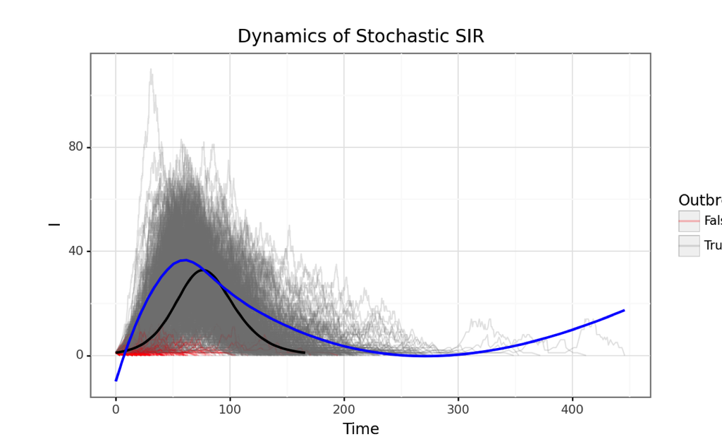

```python
import plotnine as p9
import matplotlib.pyplot as plt

finalData = pd.merge(finalData, finalData.groupby('Iteration')['S'].apply(lambda vals: np.min(vals) < 400).rename("Outbreak"),
                      on = ['Iteration'])

##Create the discrete solution
discreteSol = pd.DataFrame({'S':[499], 'I':[1], 'Time':0})
while discreteSol.I.iloc[-1] >= 1:
  newS = discreteSol.S.iloc[-1] - 1/5 * discreteSol.S.iloc[-1] * discreteSol.I.iloc[-1]/500
  newI = discreteSol.I.iloc[-1] + 1/5 * discreteSol.S.iloc[-1] * discreteSol.I.iloc[-1]/500 - 2/15 * discreteSol.I.iloc[-1]
  discreteSol = discreteSol.append(pd.DataFrame({'S': [newS], 'I': [newI], 'Time': [discreteSol.Time.iloc[-1]+1]}), ignore_index = True)

discreteSol['Iteration']=1
discreteSol['Outbreak']=True

finalData = finalData.astype({'Time':'float64', 'Iteration':'int64', 'S':'int64', 'I':'int64'})

(
p9.ggplot(finalData, p9.aes(x='Time',y='I',group='Iteration', color='Outbreak')) + p9.geom_line(alpha=0.2) + p9.theme_bw()
  + p9.scale_color_manual(values = ["red","gray"])
  + p9.geom_line(data=discreteSol, color="black", size=1)
  + p9.geom_smooth(data = finalData[finalData.Outbreak], mapping=p9.aes(x='Time', y='I'), inherit_aes=False, color = "blue", fill="lightblue", se=False, method="loess") ###need to get loess instead of GLM
  + p9.ggtitle("Dynamics of Stochastic SIR")
  )
```

We can see that there is a large amount of variability in this system. Furthermore, the smoothed version of the outbreak dynamics (blue) is considerably different than the deterministic discrete system.

## Summary of the Outbreaks

Next, the problem asks for the mean and variance of the number of sick people, the time to peak epidemic, and duration. Let’s find those quantities:

```python
Sizes = finalData.groupby('Iteration')['S'].apply(lambda x: 500 - min(x))
Sizes.mean()
```

```
165.619
```

```python
Sizes.var()
```

```
21279.032871871885
```

```python
Durations = finalData.groupby('Iteration')['Time'].max()
Durations.mean()
```

```
103.1211957856941
```

```python
Durations.var()
```

```
6683.567002492047
```

```python
PeakTime = finalData['Time'][finalData.groupby('Iteration')['I'].idxmax()]
PeakTime = PeakTime.reset_index(drop=True)
PeakTime.mean()
```

```
44.39717609700049
```

```python
PeakTime.var()
```

```
1628.9289776230282
```

```python
#just outbreaks
Sizes[Sizes > 50].mean()
```

```
290.2508896797153
```

```python
Sizes[Sizes > 50].var()
```

```
2323.3077086544727
```

```python
Durations[Sizes > 50].mean()
```

```
167.4778047535309
```

```python
Durations[Sizes > 50].var()
```

```
2145.99242650675
```

```python
PeakTime[Sizes>50].mean()
```

```
73.76854650221352
```

```python
PeakTime[Sizes>50].var()
```

```
827.0422882437167
```

Above are the summaries for the final size, time to peak, and duration of the outbreak, respectively. The second set of output is for the case of an outbreak actually happening. When there is actually an outbreak, we can expect the about 290 people to get sick (58%), with the max number of infections occurring at $t=73.8$, and lasting until $t=167$.

## Reducing N to 100

You were asked to reduce N to 100 and simulate the percentage of people who get sick. First run the simulations:

```python
np.random.seed(546696)

n100 = pd.DataFrame(columns = ["Iteration","S","I","Time"])

#use a different initial state
state100 = pd.DataFrame({"S":[99],"I":[1]}) #initial state
system100 = {"state":state100, "Time": 0}


for j in range(100):
  SIR = pd.DataFrame({'Time': system100['Time'], 'S': [system100['state']['S'][0]], 'I': system100['state']['I'][0]})

  system = system100 #reset to initial condition
  while SIR.I.iloc[-1]  > 0:
    system = update_leaping(system, N=100)
    SIR = SIR.append(pd.DataFrame({'Time': system['Time'], 'S': system['state']['S'], 'I': system['state']['I']}), ignore_index = True)

  SIR['Iteration'] = j

  n100 = n100.append(SIR,ignore_index=True)
```

Now to find the proportion that got sick:

```python
propSick = n100.groupby('Iteration')['S'].apply(lambda x: 1 - np.min(x)/100)

propSick.mean()
```

```
0.3728
```

```python
propSick.var()
```

```
0.08356581818181817
```

```python
propSick[propSick > 0.2].mean()
```

```
0.5836666666666667
```

```python
propSick[propSick > 0.2].var()
```

```
0.02525073446327683
```

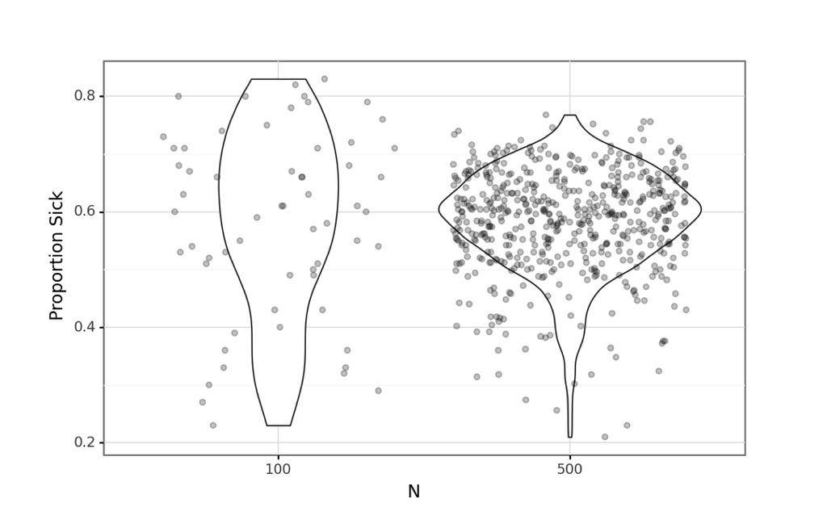

```python
plotIt = pd.DataFrame({'N':"100", 'propSick':propSick[propSick > 0.2]})
plotIt = plotIt.append(pd.DataFrame({'N':"500", 'propSick':Sizes[Sizes > 100]/500 }))

p9.ggplot(plotIt, p9.aes(x='N', y='propSick')) + p9.geom_violin() + p9.theme_bw() + p9.geom_jitter(alpha=0.2) + p9.ylab("Proportion Sick")
```

Looking at the violin plots of the two population sizes we can see that decreasing the population size increase the variance in the proportion of individuals that get sick.

## Increasing gamma to 2/11

```python
np.random.seed(234534)

g2_11 = pd.DataFrame(columns = ["Iteration","S","I","Time"])

for j in range(100):
  SIR = pd.DataFrame({'Time': system0['Time'], 'S': [system0['state']['S'][0]], 'I': system0['state']['I'][0]})

  system = system0 #reset to initial condition
  while SIR.I.iloc[-1]  > 0:
    system = update_leaping(system, gamma = 2/11)
    SIR = SIR.append(pd.DataFrame({'Time': system['Time'], 'S': system['state']['S'], 'I': system['state']['I']}), ignore_index = True)

  SIR['Iteration'] = j

  g2_11 = g2_11.append(SIR,ignore_index=True)
```

Now find the proportion of the time an outbreak occurred:

```python
Outbreaks = g2_11.groupby('Iteration')['S'].apply(lambda x: 500 - min(x) > 100)
Outbreaks.sum()/100 #percent of time an outbreak happened
```

```
0.23
```

```python
#compare with the gamma = 2/15
(Sizes > 100).sum()/1000
```

```
0.557
```

We can see that the proportion of the time an outbreak occurred changed drastically by changing $\gamma = 2/15$ to $\gamma = 2/11$. Why do you think that is?